# Overview

```r
> basicConfig()
> project_summary = "/Users/rory/cache/fabio-splicing/2016-04-26_fabio-splicing/project-summary.csv"
> counts_file = "/Users/rory/cache/fabio-splicing/2016-04-26_fabio-splicing/combined.counts"
> tx2genes_file = "/Users/rory/cache/fabio-splicing/2016-04-26_fabio-splicing/tx2gene.csv"
> cbPalette <- c("#999999", "#E69F00", "#56B4E9", "#009E73", "#F0E442", "#0072B2",
+     "#D55E00", "#CC79A7")
> summarydata = read.table(project_summary, header = TRUE, sep = ",")
> summarydata = summarydata[, colSums(is.na(summarydata)) < nrow(summarydata)]
> # handle newer bcbio-nextgen runs that use description as the key
> if ("description" %in% colnames(summarydata)) {
+     rownames(summarydata) = summarydata$description
+     summarydata$Name = rownames(summarydata)
+     summarydata$description = NULL
+ } else {
+     rownames(summarydata) = summarydata$Name
+     summarydata$Name = NULL
+ }
> summarydata = summarydata[order(rownames(summarydata)), ]
> if (file.exists(tx2genes_file)) {
+     sample_dirs = file.path("..", "..", rownames(summarydata))
+     salmon_files = file.path(sample_dirs, "salmon", "quant.sf")
+     sailfish_files = file.path(sample_dirs, "sailfish", "quant.sf")
+     new_sailfish = file.path(sample_dirs, "sailfish", "quant", "quant.sf")
+     new_salmon = file.path(sample_dirs, "salmon", "quant", "quant.sf")
+     if (file.exists(salmon_files[1])) {
+         loginfo("Using gene counts calculated from the Salmon transcript counts.")
+         sf_files = salmon_files
+     } else if (file.exists(sailfish_files[1])) {
+         loginfo("Using gene counts calculated from the Sailfish transcript counts.")
+         sf_files = sailfish_files
+     } else if (file.exists(new_sailfish[1])) {
+         loginfo("Using gene counts calculated from the Sailfish transcript counts.")
+         sf_files = new_sailfish
+     } else if (file.exists(new_salmon[1])) {
+         loginfo("Using gene counts calculated from the Salmon transcript counts.")
+         sf_files = new_salmon
+     }
+     names(sf_files) = rownames(summarydata)
+     tx2gene = read.table(tx2genes_file, sep = ",", row.names = NULL, header = FALSE)
+     txi.salmon = tximport(sf_files, type = "salmon", tx2gene = tx2gene, reader = readr::read_tsv,
+         countsFromAbundance = "lengthScaledTPM")
+     counts = round(data.frame(txi.salmon$counts, check.names = FALSE))
+ } else {
+     loginfo("Using gene counts calculated from featureCounts.")
+     counts = read.table(counts_file, header = TRUE, row.names = "id", check.names = FALSE)
+ }
```

```
2016-04-28 16:04:05 INFO::Using gene counts calculated from the Sailfish transcript counts.
```

```r
> counts = counts[, order(colnames(counts)), drop = FALSE]
> colnames(counts) = gsub(".counts", "", colnames(counts))
>
> # this is a list of all non user-supplied metadata columns that could appear
> known_columns = c("Name", "X.GC", "Exonic.Rate", "Sequences.flagged.as.poor.quality",
+     "rRNA_rate", "Fragment.Length.Mean", "Intronic.Rate", "Intergenic.Rate",
+     "Mapping.Rate", "Quality.format", "Duplication.Rate.of.Mapped", "Mapped",
+     "rRNA", "Sequence.length", "Transcripts.Detected", "Mean.Per.Base.Cov.",
+     "Genes.Detected", "Unique.Starts.Per.Read", "unique_starts_per_read", "complexity",
+     "X5.3.bias", "Duplicates.pct", "Duplicates", "Mapped.reads", "Average.insert.size",
+     "Mapped.reads.pct", "Total.reads", "avg_coverage_per_region", "Mapped.Reads")
> summarydata[, "Fragment.Length.Mean"] = summarydata$Average.insert.size
> metadata = summarydata[, !colnames(summarydata) %in% known_columns, drop = FALSE]
> metadata = metadata[, colSums(is.na(metadata)) < nrow(metadata)]
```

```r
> # set seed for reproducibility
> set.seed(1454944673)
```

```r
> get_heatmap_fn = function(summarydata) {
+     # return the pheatmap function with or without metadata
+     if (ncol(metadata) == 0) {
+         return(pheatmap)
+     } else {
+         # rownames(metadata) = summarydata$Name
+         heatmap_fn = function(data, ...) {
+             pheatmap(data, annotation = metadata, ...)
+         }
+         return(heatmap_fn)
+     }
+ }
> heatmap_fn = get_heatmap_fn(summarydata)
```

# Quality control metrics

```r
> qualimap_run = "Mapped" %in% colnames(summarydata)
> do_quality = "Mapped.reads" %in% colnames(summarydata)
```

## Mapped reads

We have a good amount of mapped reads per sample and it is fairly consistent between the samples.

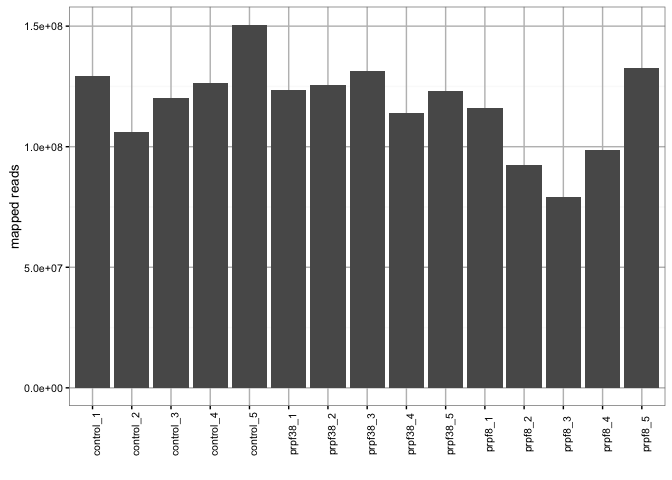

```r
> ggplot(summarydata, aes(x = Name, y = Mapped)) + theme_bw(base_size = 10) +
+     theme(panel.grid.major = element_line(size = 0.5, color = "grey"), axis.text.x = element_text(angle = 90)) +
+     geom_bar(stat = "identity") + ylab("mapped reads") + xlab("")
```

```r
> ggplot(summarydata, aes(x = Name, y = Mapped.reads)) + theme_bw(base_size = 10) +
+     theme(panel.grid.major = element_line(size = 0.5, color = "grey"), axis.text.x = element_text(angle = 90)) +
+     geom_bar(stat = "identity") + ylab("mapped reads") + xlab("")
```

## Genomic mapping rate

The genomic mapping rate is great, and mostly consistent across the samples, another good indication of quality libraries.

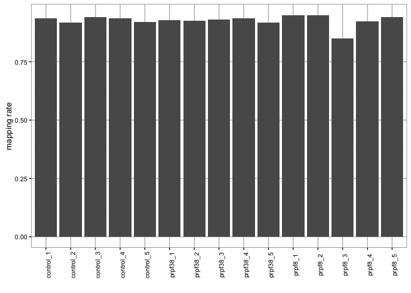

```r
> ggplot(summarydata, aes(x = Name, y = Mapping.Rate)) + geom_bar(stat = "identity") +
+     ylab("mapping rate") + xlab("") + theme_bw(base_size = 10) + theme(panel.grid.major = element_line(size = 0.5,
+     color = "grey"), axis.text.x = element_text(angle = 90))
```

```r
> ggplot(summarydata, aes(x = Name, y = Mapped.reads.pct)) + geom_bar(stat = "identity") +
+     ylab("mapping rate") + xlab("") + theme_bw(base_size = 10) + theme(panel.grid.major = element_line(size = 0.5,
+     color = "grey"), axis.text.x = element_text(angle = 90))
```

## Number of genes detected

We see a large number of genes detected in these samples, a good indication of quality.

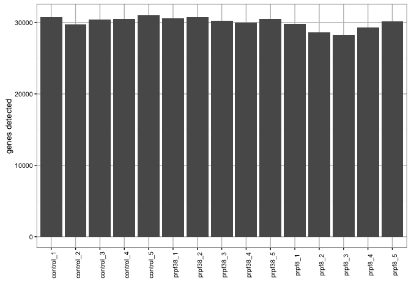

```r
> dd = data.frame(Name = colnames(counts), Genes.Detected = colSums(counts > 0))
> ggplot(dd, aes(x = Name, y = Genes.Detected)) + geom_bar(stat = "identity") +
+     theme_bw(base_size = 10) + theme(panel.grid.major = element_line(size = 0.5,
+     color = "grey"), axis.text.x = element_text(angle = 90)) + ylab("genes detected") +
+     xlab("")
```

## Gene detection saturation

We can see that as we sequence deeper, we can detect more genes.

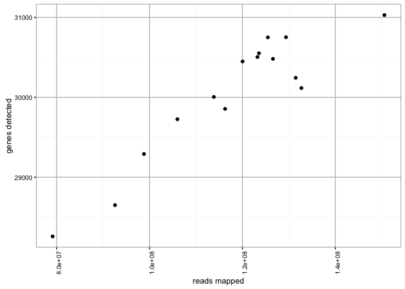

```r
> dd = data.frame(Mapped = summarydata$Mapped, Genes.Detected = colSums(counts >
+     0))
> ggplot(dd, aes(x = Mapped, y = Genes.Detected)) + geom_point() + theme_bw(base_size = 10) +
+     theme(panel.grid.major = element_line(size = 0.5, color = "grey"), axis.text.x = element_text(angle = 90)) +
+     ylab("genes detected") + xlab("reads mapped")
```

## Exonic mapping rate

The exonic mapping rate looks great, indicating we actually sequenced RNA and not genomic DNA.

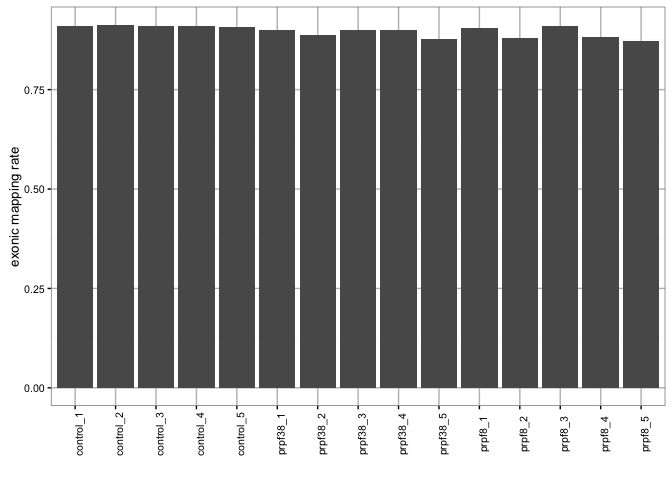

```r
> ggplot(summarydata, aes(x = Name, y = Exonic.Rate)) + geom_bar(stat = "identity") +
+     theme_bw(base_size = 10) + theme(panel.grid.major = element_line(size = 0.5,
+     color = "grey"), axis.text.x = element_text(angle = 90)) + ylab("exonic mapping rate") +
+     xlab("")
```

## rRNA mapping rate

The rRNA mapping rate has some variability, but is low like we expect.

```r
> eval_rRNA = "rRNA_rate" %in% colnames(summarydata) & !sum(is.na(summarydata$rRNA_rate)) ==
+     nrow(summarydata)
```

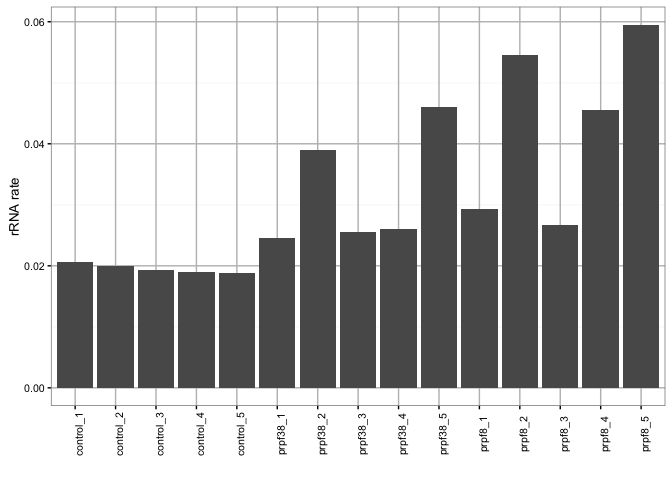

```r
> ggplot(summarydata, aes(x = Name, y = rRNA_rate)) + geom_bar(stat = "identity") +
+     theme_bw(base_size = 10) + theme(panel.grid.major = element_line(size = 0.5,
+     color = "grey"), axis.text.x = element_text(angle = 90)) + ylab("rRNA rate") +
+     xlab("")
```

## Estimated fragment length of paired-end reads

Some libraries have shorter fragment lengths than the other libraries. The overall fragment length is low, for looking at splicing grabbing lengths closer to 300 might have been better.

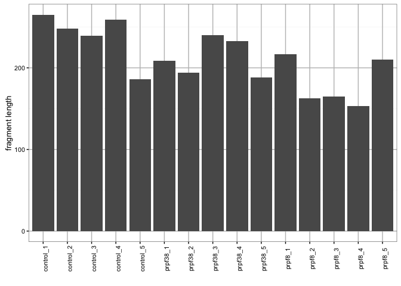

```r
> ggplot(summarydata, aes(x = Name, y = Fragment.Length.Mean)) + geom_bar(stat = "identity") +
+     theme_bw(base_size = 10) + theme(panel.grid.major = element_line(size = 0.5,
+     color = "grey"), axis.text.x = element_text(angle = 90)) + ylab("fragment length") +
+     xlab("")
```

## Boxplot of log10 counts per gene

Highly consistent. This looks awesome.

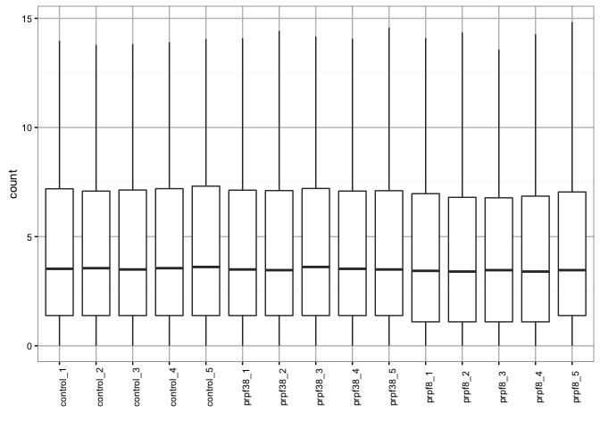

```r
> melted = melt(counts)
> colnames(melted) = c("sample", "count")
> melted$sample = factor(melted$sample)
> melted = melted[order(melted$sample), ]
> melted$count = log(melted$count)
> ggplot(melted, aes(x = sample, y = count)) + geom_boxplot() + theme_bw(base_size = 10) +
+     theme(panel.grid.major = element_line(size = 0.5, color = "grey"), axis.text.x = element_text(angle = 90)) +
+     xlab("")
```

## Boxplot of log10 TMM-normalized counts per gene

Trimmed mean of M-values (TMM) normalization is described [here](http://genomebiology.biomedcentral.com/articles/10.1186/gb-2010-11-3-r25)

Robinson, M. D., & Oshlack, A. (2010). A scaling normalization method for differential expression analysis of RNA-seq data. Genome Biology, 11(3). doi:10.1186/gb-2010-11-3-r25

Looks great.

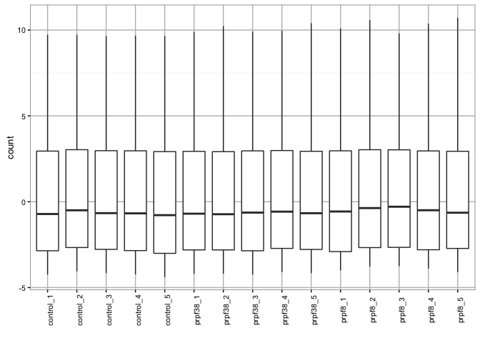

```r
> y = DGEList(counts = counts)
> y = calcNormFactors(y)
> normalized_counts = cpm(y, normalized.lib.sizes = TRUE)
> melted = melt(normalized_counts)
> colnames(melted) = c("gene", "sample", "count")
> melted$sample = factor(melted$sample)
> melted = melted[order(melted$sample), ]
> melted$count = log(melted$count)
> ggplot(melted, aes(x = sample, y = count)) + geom_boxplot() + theme_bw(base_size = 10) +
+     theme(panel.grid.major = element_line(size = 0.5, color = "grey"), axis.text.x = element_text(angle = 90)) +
+     xlab("")
```

## Density of log10 TMM-normalized counts

Beautifully consistent.

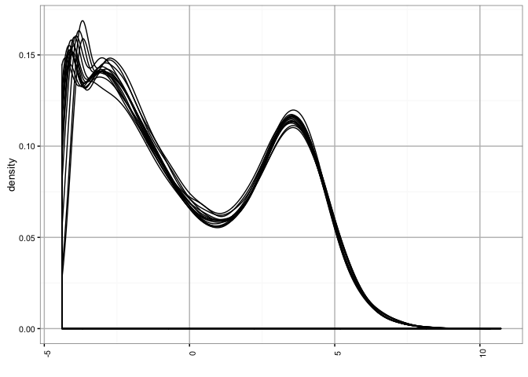

```r
> ggplot(melted, aes(x = count, group = sample)) + geom_density() + theme_bw(base_size = 10) +
+     theme(panel.grid.major = element_line(size = 0.5, color = "grey"), axis.text.x = element_text(angle = 90)) +
+     xlab("")
```

## Correlation (Pearson) heatmap of TMM-normalized counts

You can see Pearson doesn’t really cluster the samples well.

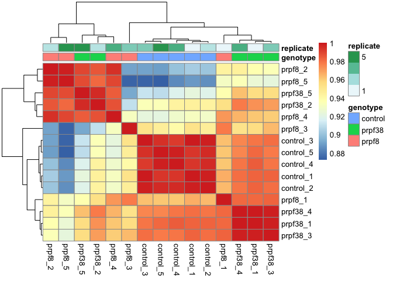

```r
> heatmap_fn(cor(normalized_counts, method = "pearson"))
```

## Correlation (Spearman) heatmap of TMM-normalized counts

Spearman gets it though.

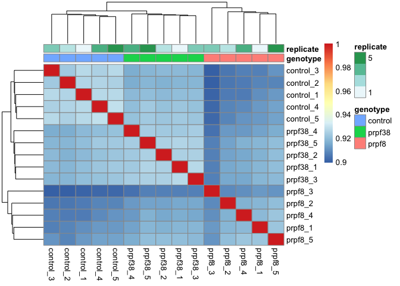

```r
> heatmap_fn(cor(normalized_counts, method = "spearman"))
```

## PCA plot

Doing PCA on the 500 most variable genes does a great job clustering the samples by genotype. We should expect to see a lot of differences between these samples, which is kind of bad if we want to look at splicing. It will make picking the splicing events out more difficult.

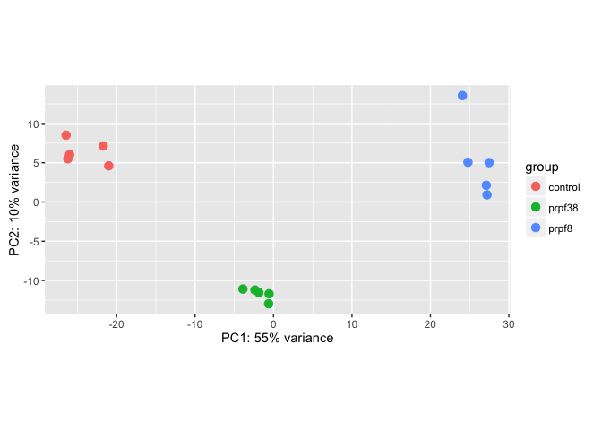

```r
> dds = DESeqDataSetFromMatrix(countData = counts, colData = summarydata, design = ~Name)
> vst = varianceStabilizingTransformation(dds)
> plotPCA(vst, intgroup = c("genotype"))
```

```r
> # snagged from development version of DESeq
> DESeqDataSetFromTximport <- function(txi, colData, design, ...) {
+     counts <- round(txi$counts)
+     mode(counts) <- "integer"
+     dds <- DESeqDataSetFromMatrix(countData = counts, colData = colData, design = design,
+         ...)
+     stopifnot(txi$countsFromAbundance %in% c("no", "scaledTPM", "lengthScaledTPM"))
+     if (txi$countsFromAbundance %in% c("scaledTPM", "lengthScaledTPM")) {
+         message("using length scaled TPM counts from tximport")
+     } else {
+         message("using counts and average transcript lengths from tximport")
+         lengths <- txi$length
+         dimnames(lengths) <- dimnames(dds)
+         assays(dds)[["avgTxLength"]] <- lengths
+     }
+     return(dds)
+ }
>
> subset_tximport = function(txi, rows, columns) {
+     txi$counts = txi$counts[rows, columns]
+     txi$abundance = txi$abundance[rows, columns]
+     txi$length = txi$length[rows, columns]
+     return(txi)
+ }
```

```r
> library(DEGreport)
> library(vsn)
> design = ~genotype
> condition = "genotype"
```

# Differential expression

```r
> counts <- counts[rowSums(counts > 0) > 1, ]
> if (exists("txi.salmon")) {
+     loginfo("Using Sailfish gene counts for the DESeq2 model.")
+     txi.salmon = subset_tximport(txi.salmon, rownames(counts), colnames(counts))
+     dds = DESeqDataSetFromTximport(txi.salmon, colData = summarydata, design = design)
+ } else {
+     loginfo("Using counts from featureCounts for the DESeq2 model.")
+     dds = DESeqDataSetFromMatrix(countData = counts, colData = summarydata,
+         design = design)
+ }
```

2016-04-28 16:04:44 INFO::Using Sailfish gene counts for the DESeq2 model.

```r
> geoMeans = apply(counts, 1, function(row) if (all(row == 0)) 0 else exp(mean(log(row[row !=
+     0]))))
> dds = estimateSizeFactors(dds, geoMeans = geoMeans)
> dds = DESeq(dds)
```

## Effect of variance stabilization

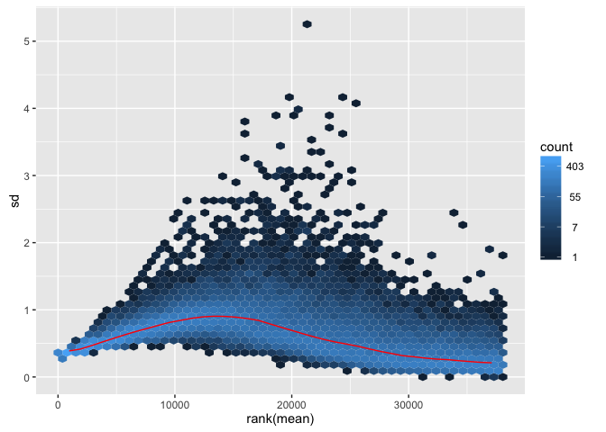

```r
> par(mfrow = c(1, 3))
> notAllZero <- (rowSums(counts(dds)) > 0)
> rld <- rlog(dds)
> vsd <- varianceStabilizingTransformation(dds)
> rlogMat <- assay(rld)
> vstMat <- assay(vsd)
>
> meanSdPlot(log2(counts(dds, normalized = TRUE)[notAllZero, ] + 1))
```

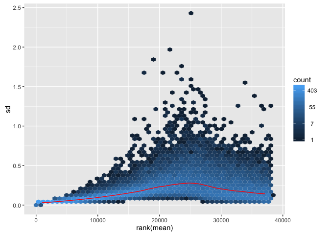

```r
> meanSdPlot(assay(rld[notAllZero, ]))
```

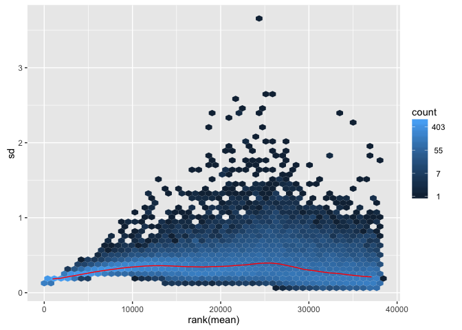

```r
> meanSdPlot(assay(vsd[notAllZero, ]))
```

## Dispersion estimates

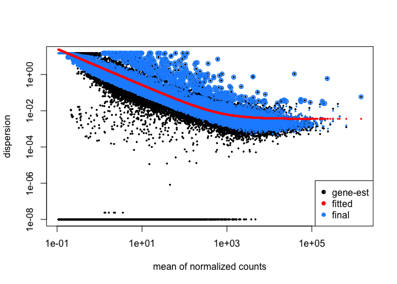

```r
> plotDispEsts(dds)
```

```r
> handle_deseq2 = function(dds, summarydata, column) {
+     all_combs = combn(levels(summarydata[, column]), 2, simplify = FALSE)
+     all_results = list()
+     contrast_strings = list()
+     for (comb in all_combs) {
+         contrast_string = paste(comb, collapse = " vs ")
+         contrast = c(column, comb)
+         res = results(dds, contrast = contrast)
+         res = res[order(res$padj), ]
+         all_results = c(all_results, res)
+         contrast_strings = c(contrast_strings, contrast_string)
+     }
+     names(all_results) = contrast_strings
+     return(all_results)
+ }
```

```r
> library(biomaRt)
> library(dplyr)
> human = useMart(biomart = "ENSEMBL_MART_ENSEMBL", dataset = "hsapiens_gene_ensembl",
+     host = "jul2015.archive.ensembl.org")
> symbols = getBM(attributes = c("ensembl_gene_id", "hgnc_symbol"), mart = human)
> join_biomart = function(res, symbols) {
+     res = data.frame(res)
+     res$id = rownames(res)
+     res = res %>% left_join(symbols, by = c(id = "ensembl_gene_id"))
+     res = res[order(res$padj), ]
+     return(res)
+ }
```

## Differential expression

For these comparisons, positive log2 fold changes are higher in `PRPF8` and `PRPF38` knockouts than the `control` samples. There are a lot of genes different for both samples, which means it might be tough to pick out splicing differences.

## PRP8 vs control

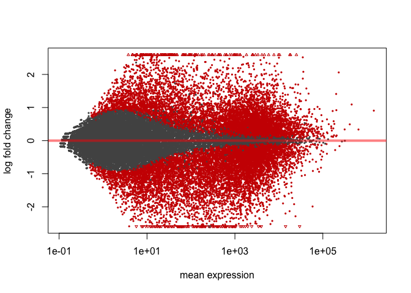

```r
> prpf8 = results(dds, contrast = c("genotype", "prpf8", "control"))
> plotMA(prpf8)
```

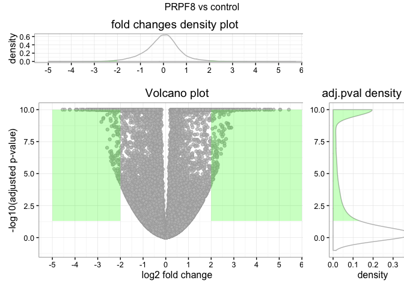

```r
> prpf8 = as.data.frame(prpf8)
> volcano_density_plot(prpf8[, c(2, 6)], title = "PRPF8 vs control", lfc.cutoff = 2)
```

```r
> prpf8 = join_biomart(prpf8, symbols)
> write.table(prpf8, file = "prpf8-vs-control.csv", col.names = TRUE, row.names = FALSE,
+     quote = FALSE, sep = ",")
```

ihere are 14475 genes differentially expressed between the `PRPF8` and the `control` samples.

## PRPF38 vs control

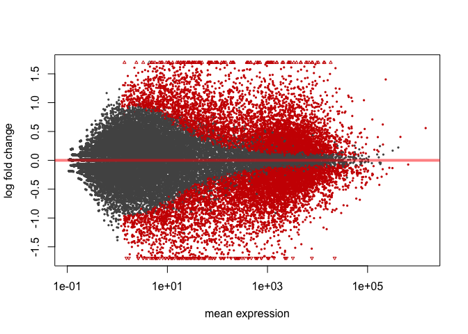

```r
> prpf38 = results(dds, contrast = c("genotype", "prpf38", "control"))
> plotMA(prpf38)
```

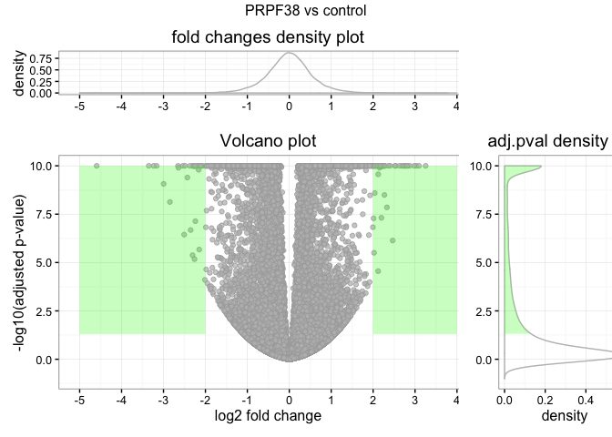

```r
> prpf38 = as.data.frame(prpf38)
> volcano_density_plot(prpf38[, c(2, 6)], title = "PRPF38 vs control", lfc.cutoff = 2)
```

```r
> prpf38 = join_biomart(prpf38, symbols)
> write.table(prpf38, file = "prpf38-vs-control.csv", col.names = TRUE, row.names = FALSE,
+     quote = FALSE, sep = ",")
```

ihere are 11038 genes differentially expressed between the `PRPF38` and the `control` samples.

### Mean-vs-Variation

This is a diagnostic plot to make sure we aren’t calling genes differentially expressed just because we didn’t model the mean-variance relationship very well. These look good, most of our calls are within what we’d expect.

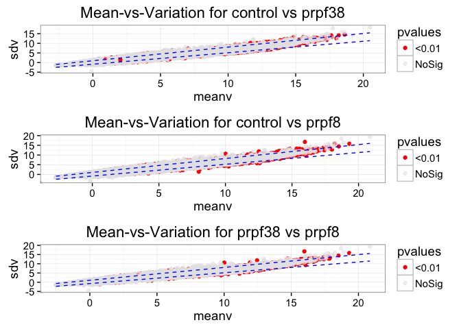

```r
> plots = list()
> for (i in seq(length(all_results))) {
+     g <- get_groups(summarydata, names(all_results)[i], condition)
+     if (length(g[[1]]) < 2 | length(g[[2]]) < 2) {
+         next
+     }
+     plots[[i]] = degMV(g[[1]], g[[2]], all_results[[i]]$pvalue, counts(dds,
+         normalized = TRUE)) + theme_bw(base_size = scale_factor) + ggtitle(paste0("Mean-vs-Variation for ",
+         names(all_results)[i]))
+ }
> if (length(plots) > 0) {
+     do.call(grid.arrange, plots)
+ }
```

# Summary

These libraries look awesome, some of the best RNA-seq libraries I have seen in a long time. We find a huge amount of differential expression at the gene level between these samples, which might make it hard to look at splicing differences. We could also be falsely calling gene level differential expression if there is a large amount of splicing differences between the samples. The next step is to look at splicing differences between the samples, we’ll do that first at the transcript level, since that will have the most easily interpretable results. After that we will look at sub-exon level with DEXSeq and then move on to event level descriptions which will require more work.

# Links

PRPF8 vs control results

PRPF38 vs control results